# Titanic

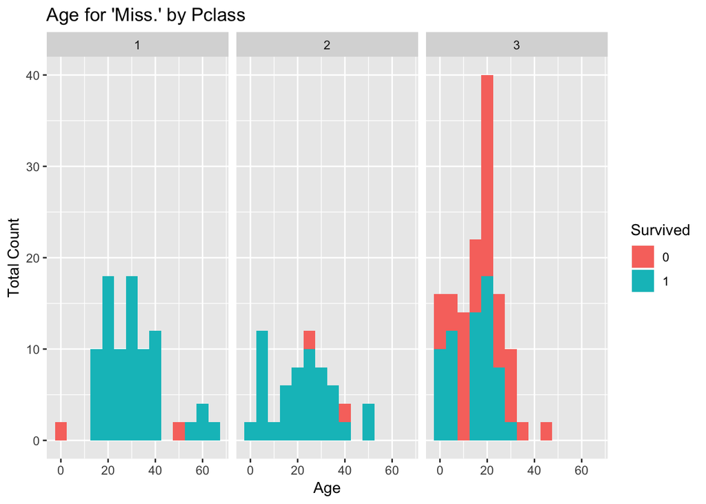

```r
ggplot(misses[misses$Survived != "None",], aes(x = Age, fill = Survived)) +
  facet_wrap(~Pclass) +
  geom_histogram(binwidth = 5) +
  ggtitle("Age for 'Miss.' by Pclass") +
  xlab("Age") +
  ylab("Total Count")
```

Appears female children may have different survival rate, could be a candidate for feature engineering later

```r
misses.alone <- misses[which(misses$SibSp == 0 & misses$Parch == 0),]
summary(misses.alone$Age)
```

```
##    Min. 1st Qu.  Median    Mean 3rd Qu.    Max.    NA's
##    5.00   21.00   26.00   27.74   34.00   58.00      44
```

```r
length(which(misses.alone$Age <= 14.5))
```

```
## [1] 6
```

```r
# Move on to the sibsp variable, summarize the variable
summary(data.combined$SibSp)
```

```
##    Min. 1st Qu.  Median    Mean 3rd Qu.    Max.
##   0.000   0.000   0.000   0.523   1.000   8.000
```

```r
# Can we treat as a factor?
length(unique(data.combined$SibSp))
```

```
## [1] 7
```

```r
data.combined$SibSp <- as.factor(data.combined$SibSp)
```

We believe title is predictive. Visualize survival reates by sibsp, pclass, and title

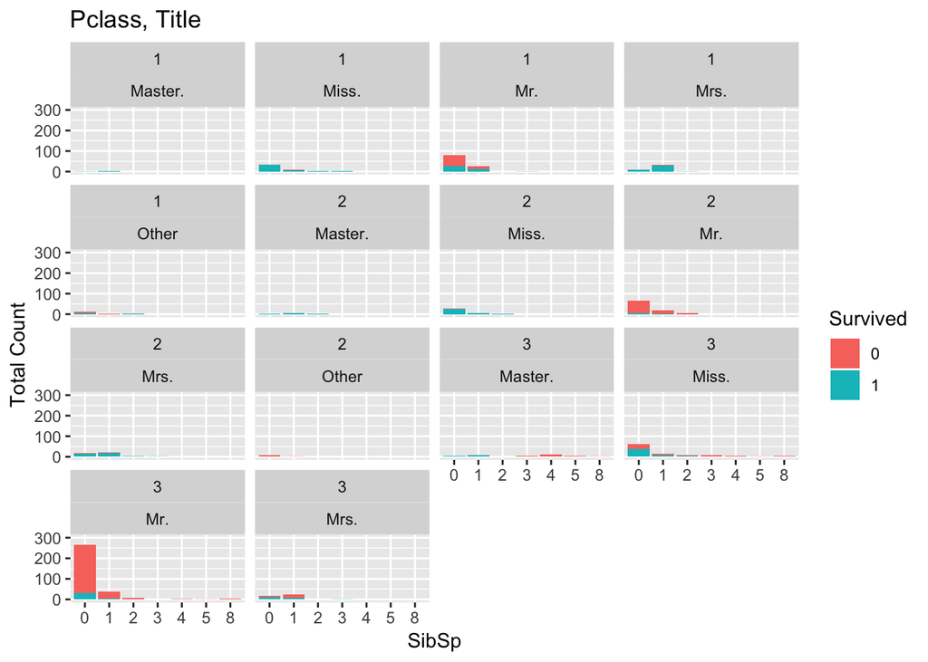

```r
ggplot(data.combined[1:891,], aes(x = SibSp, fill = Survived)) +
geom_bar() +
  facet_wrap(~Pclass + title) +
  ggtitle("Pclass, Title") +
  xlab("SibSp") +
  ylab("Total Count") +
  ylim(0,300)
```

```r
  labs(fill = "Survived")
```

```
## $fill
## [1] "Survived"
##
## attr(,"class")
## [1] "labels"
```

Treat the parch vaiable as a factor and visualize

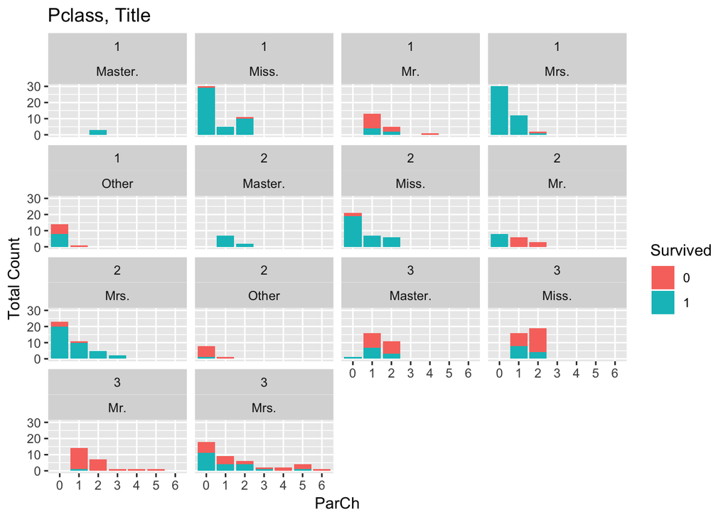

```r
data.combined$Parch <- as.factor(data.combined$Parch)
ggplot(data.combined[1:891,], aes(x = Parch, fill = Survived)) +
  geom_bar() +
  facet_wrap(~Pclass + title) +
  ggtitle("Pclass, Title") +
  xlab("ParCh") +
  ylab("Total Count") +
  ylim(0,30) +
  labs(fill = "Survived")
```

Let’s try some feature engineering. What about creating a family size feature?

```r
temp.SibSp <- c(train$SibSp, test$SibSp)
temp.Parch <- c(train$Parch, test$Parch)
data.combined$family.size <- as.factor(temp.SibSp + temp.Parch + 1)
```

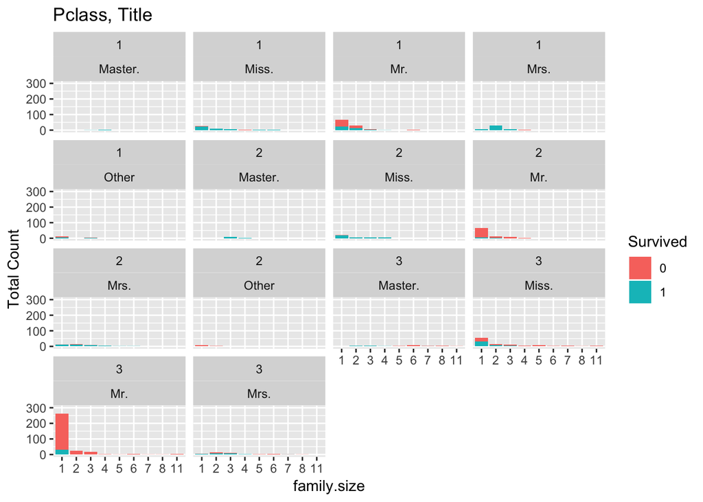

```r
# Visualize it to see if it is predictive
ggplot(data.combined[1:891,], aes(x = family.size, fill = Survived)) +
  geom_bar() +
  facet_wrap(~Pclass + title) +
  ggtitle("Pclass, Title") +
  xlab("family.size") +
  ylab("Total Count") +
  ylim(0,300) +
  labs(fill = "Survived")
```

Take a look at the ticket variable

```r
str(data.combined$Ticket)
```

```
##  Factor w/ 681 levels "110152","110413",..: 524 597 670 50 473 276 86 396 345 133 ...
```

Based on the huge number of levels ticket really isn’t a factor variable it is a string.

```r
data.combined$Ticket <- as.character(data.combined$Ticket)
data.combined$Ticket[1:5]
```

```
## [1] "A/5 21171"        "PC 17599"         "STON/O2. 3101282"
## [4] "113803"           "373450"
```

There’s no immediately apparent structure in the data, let’s see if we can find some.We’ll start with taking a look at just the first char for each

```r
ticket.first.char <-  substr(data.combined$Ticket, 1, 1)
unique(ticket.first.char)
```

```
##  [1] "A" "P" "S" "1" "3" "2" "C" "7" "W" "4" "F" "L" "9" "6" "5" "8"
```

OK, we can make a factor for analysis purposes and visualize

```r
data.combined$ticket.first.char <- as.factor(ticket.first.char)
```

Lets plot survival rate for each class of ticket

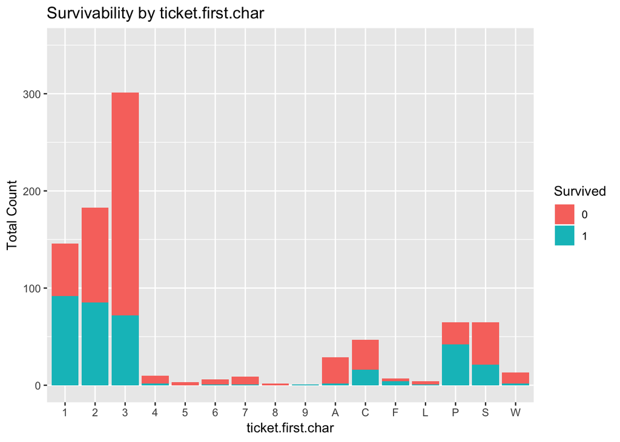

```r
ggplot(data.combined[1:891,], aes(x = ticket.first.char, fill = Survived)) +
  geom_bar() +
  ggtitle("Survivability by ticket.first.char") +
  xlab("ticket.first.char") +
  ylab("Total Count") +
  ylim(0,350) +
  labs(fill = "Survived")
```

Ticket seems like it might be predictive, drill down a bit

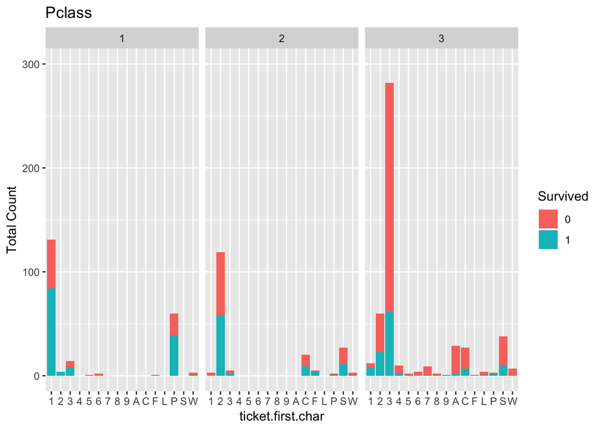

```r
ggplot(data.combined[1:891,], aes(x = ticket.first.char, fill = Survived)) +
  geom_bar() +
  facet_wrap(~Pclass) +
  ggtitle("Pclass") +
  xlab("ticket.first.char") +
  ylab("Total Count") +
  ylim(0,300) +
  labs(fill = "Survived")
```

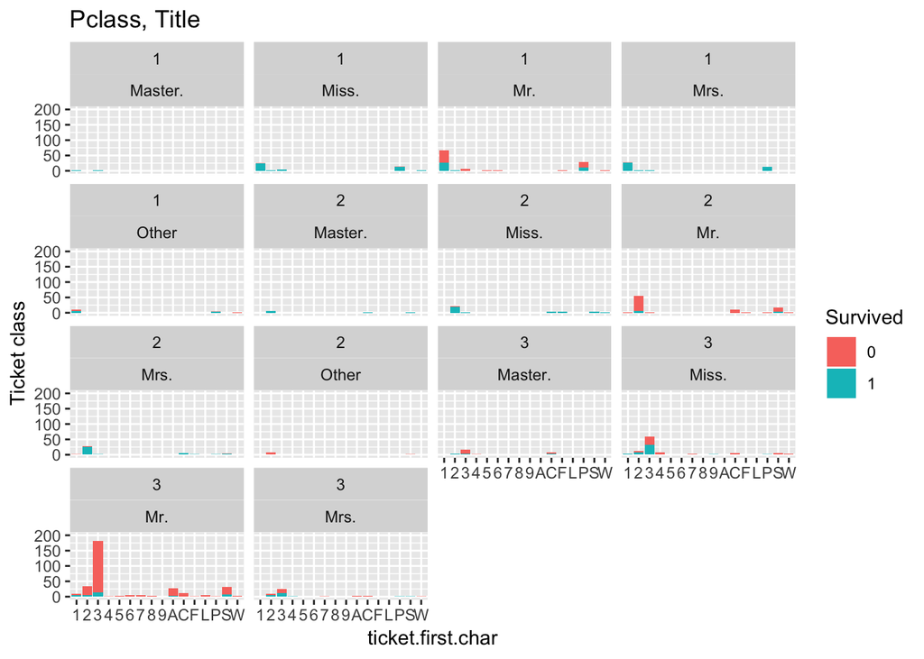

```r
ggplot(data.combined[1:891,], aes(x = ticket.first.char, fill = Survived)) +
  geom_bar() +
  facet_wrap(~Pclass+title) +
  ggtitle("Pclass, Title") +
  xlab("ticket.first.char") +
  ylab("Ticket class") +
  ylim(0,200) +
  labs(fill = "Survived")
```

Next up - the fares Titanic passengers paid

```r
summary(data.combined$Fare)
```

```
##    Min. 1st Qu.  Median    Mean 3rd Qu.    Max.
##   0.000   7.903  14.454  32.204  31.000 512.329
```

```r
length(unique(data.combined$Fare))
```

```
## [1] 248
```

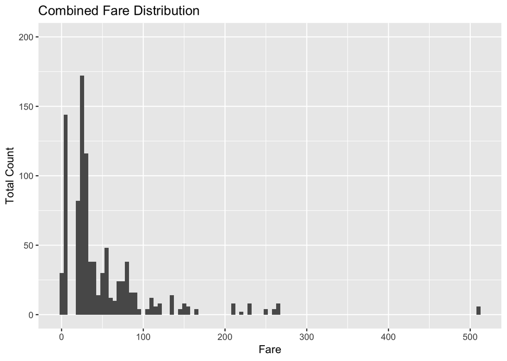

```r
#Can't make fare a factor, treat as numeric & visualize with histogram
ggplot(data.combined, aes(x = Fare)) +
  geom_histogram(binwidth = 5) +
  ggtitle("Combined Fare Distribution") +
  xlab("Fare") +
  ylab("Total Count") +
  ylim(0,200)
```

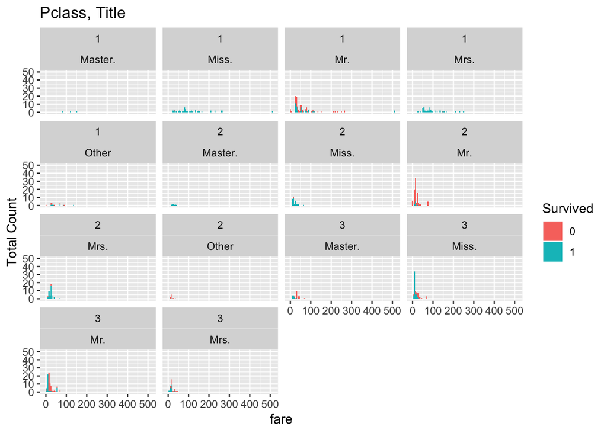

```r
# Let's check to see if fare has predictive power
ggplot(data.combined[1:891,], aes(x = Fare, fill = Survived)) +
  geom_histogram(binwidth = 5) +
  facet_wrap(~Pclass + title) +
  ggtitle("Pclass, Title") +
  xlab("fare") +
  ylab("Total Count") +
  ylim(0,50)
```

```r
  labs(fill = "Survived")
```

```
## $fill
## [1] "Survived"
##
## attr(,"class")
## [1] "labels"
```

```r
# Analysis of the cabin variable
str(data.combined$Cabin)
```

```
##  Factor w/ 148 levels "","A10","A14",..: 1 83 1 57 1 1 131 1 1 1 ...
```

```r
#Cabin really isn't a factor, make a string and the display first 100
data.combined$Cabin <- as.character(data.combined$Cabin)
data.combined$Cabin[1:5]
```

```
## [1] ""     "C85"  ""     "C123" ""
```

There are missing cabin values. Replace empty cabins with a “U”

```r
data.combined[which(data.combined$Cabin == ""), "Cabin"] <- "U"
data.combined$Cabin[1:10]
```

```
##  [1] "U"    "C85"  "U"    "C123" "U"    "U"    "E46"  "U"    "U"    "U"
```

Take a look at the 1st character of the cabin

```r
cabin.first.char <- as.factor(substr(data.combined$Cabin, 1, 1))
str(cabin.first.char)
```

```
##  Factor w/ 9 levels "A","B","C","D",..: 9 3 9 3 9 9 5 9 9 9 ...
```

```r
levels(cabin.first.char)
```

```
## [1] "A" "B" "C" "D" "E" "F" "G" "T" "U"
```

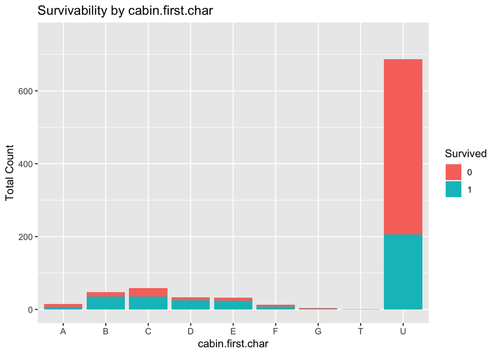

```r
 # Add to combined data set and plot
data.combined$cabin.first.char <- cabin.first.char

# High level plot
ggplot(data.combined[1:891,], aes(x = cabin.first.char, fill = Survived)) +
  geom_bar() +
  ggtitle("Survivability by cabin.first.char") +
  xlab("cabin.first.char") +
  ylab("Total Count") +
  ylim(0,750) +
  labs(fill = "Survived")
```

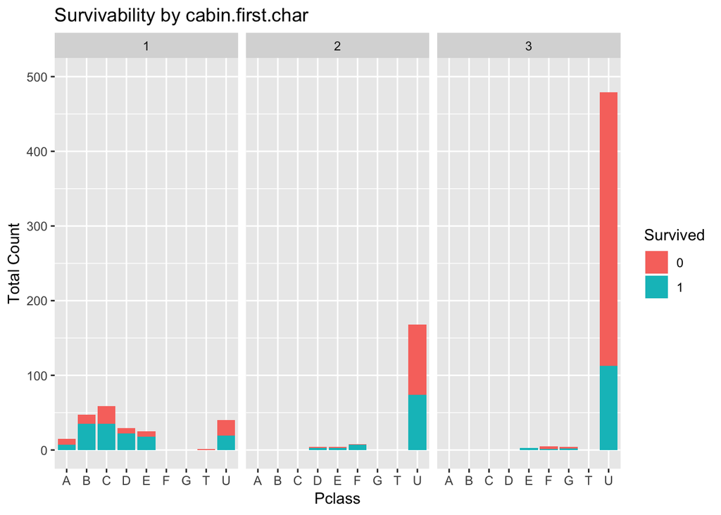

```r
# Could have some predictive power, drill in
ggplot(data.combined[1:891,], aes(x = cabin.first.char, fill = Survived)) +
  geom_bar() +
  facet_wrap(~Pclass) +
  ggtitle("Survivability by cabin.first.char") +
  xlab("Pclass") +
  ylab("Total Count") +
  ylim(0,500) +
  labs(fill = "Survived")
```

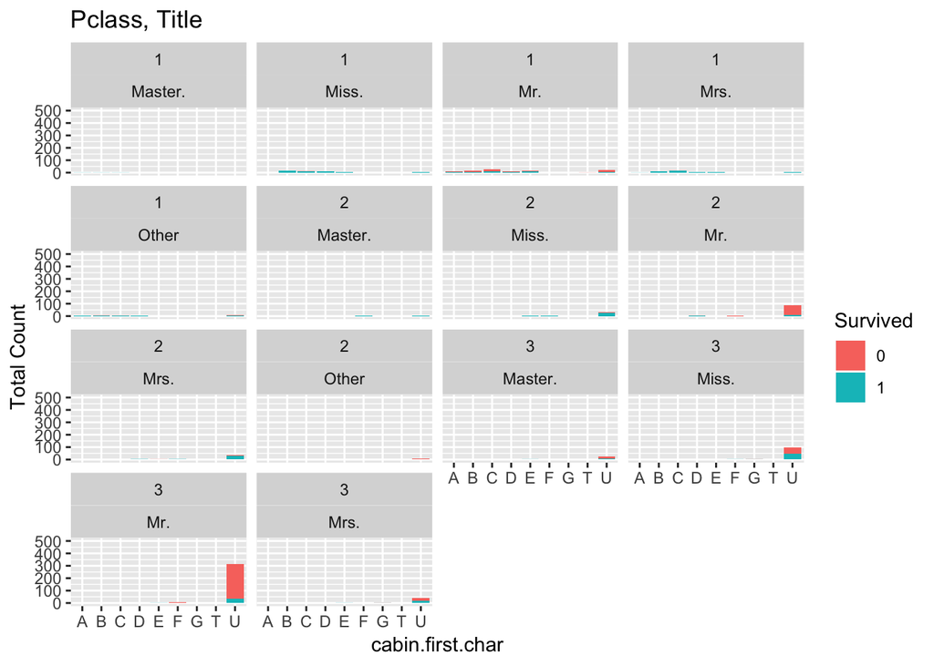

```r
# Does this feature improve upon pclass + title?
ggplot(data.combined[1:891,], aes(x = cabin.first.char, fill = Survived)) +
  geom_bar() +
  facet_wrap(~Pclass + title) +
  ggtitle("Pclass, Title") +
  xlab("cabin.first.char") +
  ylab("Total Count") +
  ylim(0,500) +
  labs(fill = "Survived")
```

```r
# Does survivability depend on where you got onboard the Titanic?
str(data.combined$Embarked)
```

```
##  Factor w/ 4 levels "","C","Q","S": 4 2 4 4 4 3 4 4 4 2 ...
```

```r
levels(data.combined$Embarked)
```

```
## [1] ""  "C" "Q" "S"
```

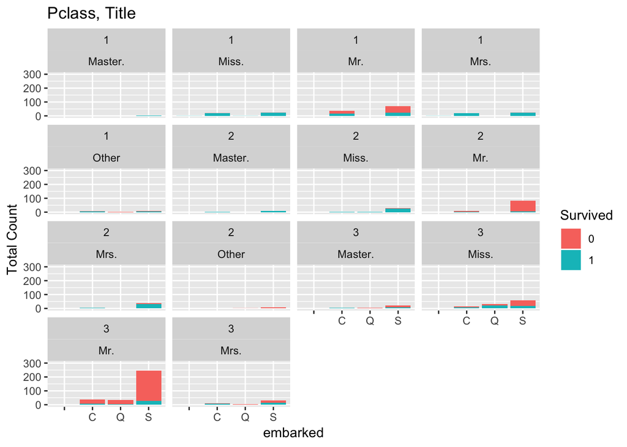

```r
# Plot data for analysis
ggplot(data.combined[1:891,], aes(x = Embarked, fill = Survived)) +
  geom_bar() +
  facet_wrap(~Pclass + title) +
  ggtitle("Pclass, Title") +
  xlab("embarked") +
  ylab("Total Count") +
  ylim(0,300) +
  labs(fill = "Survived")
```

## Exploratory Modeling

```r
library(randomForest)
# Train a Random Forest with the default parameters using pclass & title
rf.train.1 <- data.combined[1:891, c("Pclass", "title")]
rf.label <- as.factor(train$Survived)

set.seed(1234)
rf.1 <- randomForest(x = rf.train.1, y = rf.label, importance = TRUE, ntree = 1000)
rf.1
```

```
##
## Call:
##  randomForest(x = rf.train.1, y = rf.label, ntree = 1000, importance = TRUE)
##                Type of random forest: classification
##                      Number of trees: 1000
## No. of variables tried at each split: 1
##
##         OOB estimate of  error rate: 20.99%
## Confusion matrix:
##     0   1 class.error
## 0 536  13  0.02367942
## 1 174 168  0.50877193
```

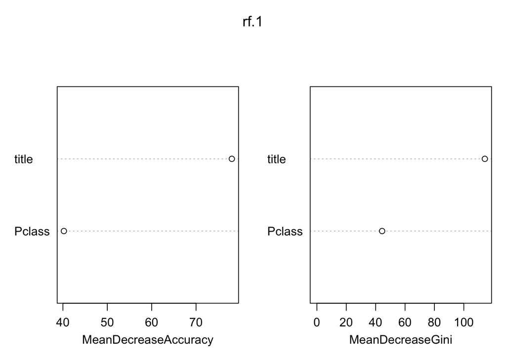

```r
varImpPlot(rf.1)
```

```r
# Train a Random Forest using pclass, title, & sibsp
rf.train.2 <- data.combined[1:891, c("Pclass", "title", "SibSp")]

set.seed(1234)
rf.2 <- randomForest(x = rf.train.2, y = rf.label, importance = TRUE, ntree = 1000)
rf.2
```

```
##
## Call:
##  randomForest(x = rf.train.2, y = rf.label, ntree = 1000, importance = TRUE)
##                Type of random forest: classification
##                      Number of trees: 1000
## No. of variables tried at each split: 1
##
##         OOB estimate of  error rate: 19.53%
## Confusion matrix:
##     0   1 class.error
## 0 487  62   0.1129326
## 1 112 230   0.3274854
```

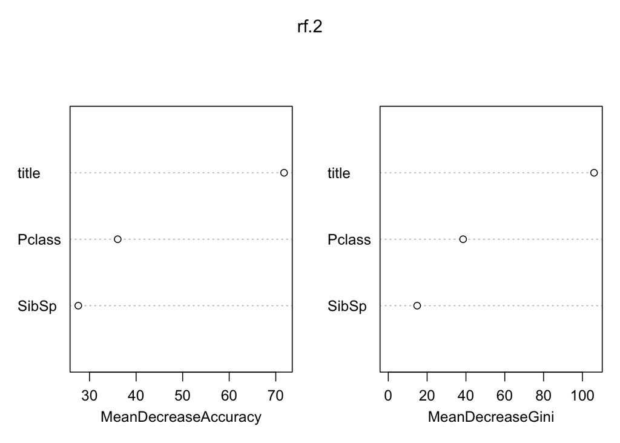

```r
varImpPlot(rf.2)
```

Definately title is a very important feature

Lets see with parent with child (parch)

```r
# Train a Random Forest using pclass, title, & parch
rf.train.3 <- data.combined[1:891, c("Pclass", "title", "Parch")]

set.seed(1234)
rf.3 <- randomForest(x = rf.train.3, y = rf.label, importance = TRUE, ntree = 1000)
rf.3
```

```
##
## Call:
##  randomForest(x = rf.train.3, y = rf.label, ntree = 1000, importance = TRUE)
##                Type of random forest: classification
##                      Number of trees: 1000
## No. of variables tried at each split: 1
##
##         OOB estimate of  error rate: 19.87%
## Confusion matrix:
##     0   1 class.error
## 0 496  53  0.09653916
## 1 124 218  0.36257310
```

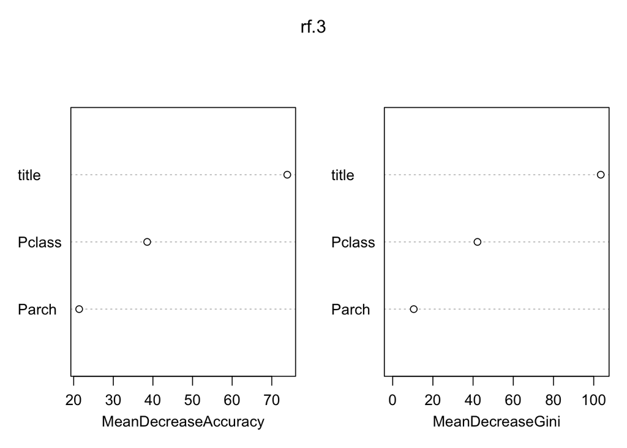

```r
varImpPlot(rf.3)
```

Train a Random Forest using pclass, title, & family.size

```r
rf.train.4 <- data.combined[1:891, c("Pclass", "title", "family.size")]

set.seed(1234)
rf.4 <- randomForest(x = rf.train.4, y = rf.label, importance = TRUE, ntree = 1000)
rf.4
```

```
##
## Call:
##  randomForest(x = rf.train.4, y = rf.label, ntree = 1000, importance = TRUE)
##                Type of random forest: classification
##                      Number of trees: 1000
## No. of variables tried at each split: 1
##
##         OOB estimate of  error rate: 18.18%
## Confusion matrix:
##     0   1 class.error
## 0 486  63   0.1147541
## 1  99 243   0.2894737
```

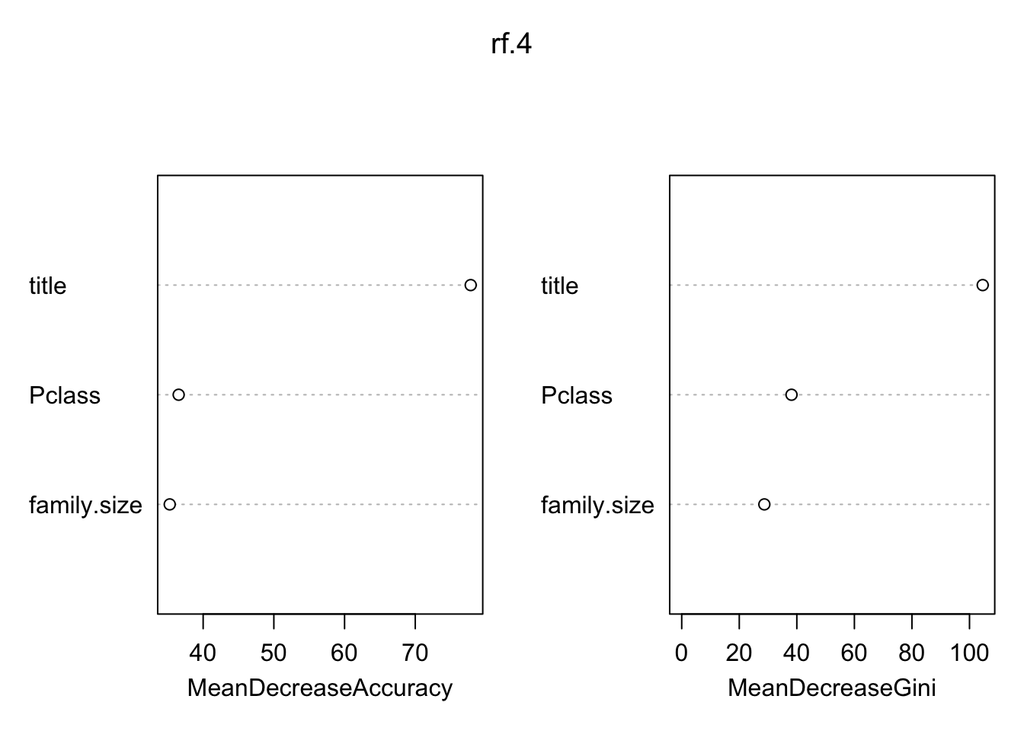

```r
varImpPlot(rf.4)
```

```r
#Train a Random Forest using pclass, title, sibsp, & family.size
rf.train.6 <- data.combined[1:891, c("Pclass", "title", "SibSp", "family.size")]

set.seed(1234)
rf.6 <- randomForest(x = rf.train.6, y = rf.label, importance = TRUE, ntree = 1000)
rf.6
```

```
##
## Call:
##  randomForest(x = rf.train.6, y = rf.label, ntree = 1000, importance = TRUE)
##                Type of random forest: classification
##                      Number of trees: 1000
## No. of variables tried at each split: 2
##
##         OOB estimate of  error rate: 19.64%
## Confusion matrix:
##     0   1 class.error
## 0 487  62   0.1129326
## 1 113 229   0.3304094
```

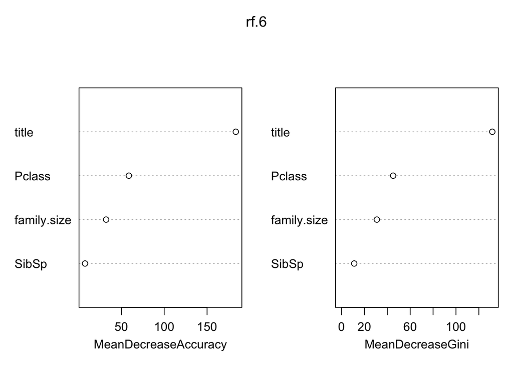

```r
varImpPlot(rf.6)
```